# hhh4addon: extending the functionality of surveillance:hhh4

Johannes Bracher (johannes.bracher@uzh.ch), University of Zurich

2020-04-19

## Purpose of the `R` package `hhh4addon`

The `R` package `hhh4addon` extends the functionality of the `surveillance` package (Meyer et al 2017), more specifically the implementation of the endemic-epidemic model class in the function `hhh4`. It adds the following features:

- Fitting models with higher-order lags.
- Computation of predictive and marginal (stationary/periodically stationary) first and second moments.

As `hhh4addon` can only be used in combination with `surveillance` we assume familiarity with this package and in particular the `hhh4` function in the following.

## The endemic-epidemic model class and its extension to higher-order lags

We only give a brief description of the endemic-epidemic framework and the `hhh4` function, details can be found in Meyer et al (2017) and the vignettes `vignette("hhh4")` and `vignette("hhh4_spacetime")` from the `surveillance` package. Counts $X_{it}$ from units $i = 1, ..., m$ and time $t$ are modelled as

$$X_{it} \mid \mathbf{X}_{t - 1} \sim \text{NegBin}(\mu_{it}, \psi_i); X_{it} \bot X_{jt} \mid \mathbf{X}_{t - 1}$$
$$\mu_{it} = e_{it}\nu_{it} + \lambda_{it}X_{i, t - 1} + \phi_{it}\sum_{j \neq i} \lfloor w_{ji}\rfloor X_{j, t - 1}.$$
Here, the negative binomial distribution is parametrized by its mean $\mu_{it}$ and an overdispersion parameter $\psi_i$ so that $\text{Var}(X_t \mid \mathbf{X}_{t - 1}) = \mu_{it}\cdot(1 + \psi_i\mu_{it})$. The term $e_{it}\nu_{it}$ is referred to as the endemic component of incidence, where $e_{it}$ is a population offset. The remaining autoregressive terms form the epidemic component, with $\lambda_{it}X_{i, t - 1}$ often called the autoregressive part and $\phi_{it}\sum_{j \neq i} w_{ji}X_{j, t - 1}$ the neighbourhood part. Various specifications for the normalized weights $\lfloor w_{ij}\rfloor$ exist, see `vignette("hhh4_spacetime")` from the surveillance package. The parameters $\nu_{it}, \lambda_{it}$ and $\phi_{it}$ are themselves modelled in a log-linear fashion. While in principle covariates can enter here, it is common to include only an intercept and sine/cosine terms for seasonality, e.g.
$$\log(\nu_{it}) = \alpha^{(\nu)}_i + \beta^{(\nu)}_i \sin(2\pi t/\omega) + \gamma^{(\nu)}_i \cos(2\pi t/\omega),$$
$$\log(\lambda_{it}) = \alpha^{(\lambda)}_i + \beta^{(\lambda)}_i \sin(2\pi t/\omega) + \gamma^{(\lambda)}_i \cos(2\pi t/\omega),$$
$$\log(\phi_{it}) = \alpha^{(\phi)}_i + \beta^{(\phi)}_i \sin(2\pi t/\omega) + \gamma^{(\phi)}_i \cos(2\pi t/\omega).$$
Models of this type can be fitted using the function `hhh4` from `surveillance`. Numerous aspects of the model can be specified via the `control` list, with the parametrization of $\nu_{it}$, $\lambda_{it}$ and $\phi_{it}$ steered by the elements `end`, `ar` and `ne`. Whether unit-specific parameters are necessary and identifiable depends on the data at hand, see the vignettes from `surveillance` for more information on model building.

The additional functionality offered by `hhh4addon` is the inclusion of higher-order lags, i.e. it provides methods to fit models of the form
$$X_{it} \mid \mathbf{X}_{t - 1}, ..., \mathbf{X}_{t - D}, \sim \text{NegBin}(\mu_{it}, \psi_i)$$
$$\mu_{it} = \nu_{it} + \lambda_{it}\sum_{d = 1}^D \lfloor u_d\rfloor X_{i, t - d} + \phi_{it}\sum_{j\neq i}\sum_{d = 1}^D \lfloor w_{ji}\rfloor \lfloor u_d\rfloor X_{j, t - d}$$
where the weights $u_d$ are normalized so that $\sum_{d = 1}^D \lfloor u_d\rfloor = 1$. This means that instead of the previous observation $\mathbf{X}_{t - 1}$ a weighted average of the $D$ preceding observations $\mathbf{X}_{t - 1},\dots, \mathbf{X}_{t - D}$ enters. Note that the weights $u_d$ are shared between the autoregressive and neighbourhood component and it is not possible to specify them separately.

Currently four parameterizations of the weights $u_d$ are implemented. The default is a geometric, i.e. exponentially decaying lag weighting structure
$$u_d = \alpha(1 - \alpha)^{d - 1}, \ \ \alpha \in (0, 1).$$
A second option is a (shifted) Poisson weighting,
$$u_d = \frac{\alpha^{d - 1}}{(d - 1)!}\exp(-\alpha), \ \ \alpha > 0$$
which unlike the geometric formulation does not force the first lag weight $u_1$ to be the largest. Thirdly there are linearly decaying lag weights,
$$u_d = \max(1 - \alpha d, 0), \ \ \alpha \in (0, 1).$$
The last pre-implemented lag structure is a simple AR(2) version with
$$u_1 = \alpha,\ \ \ u_2 = 1 - \alpha, \ \ \ \alpha \in (0, 1).$$

When `hhh4addon` is loaded, a modified version `hhh4lag` of `hhh4` is available. The following additional specifications can be made in the `control` list:

- `funct_lag`: a function to compute lag weights from a (scalar) parameter `par_lag`. Moreover the function needs to take the smallest and largest lag to receive a positive weight as arguments (`min_lag` and `max_lag`). The four parameterizations mentioned above can be specified (implemented in the functions `geometric lag`, `poisson_lag`, `linear_lag` and `ar2_lag`). Alternatively a user-defined function can be provided. For this case we recommend to consult the source code of e.g. `geometric_lag` and adapt it accordingly.
- `par_lag`: the weighting parameter entering into `funct_lag`; for `geometric_lag`, `linear_lag` and `ar2_lag` this is $\text{logit}(\alpha)$, for `poisson_lag` it is $\log(\alpha)$. These choices enable unconstrained optimization of the (profile) likelihood, when $\alpha$ is estimated from the data (see below).
- `min_lag`: the lowest lag to receive a positive weight (the weights for lags 1 through `par_lag - 1` are forced to zero). The default value 1 should be kept in most cases.
- `max_lag`: the highest lag to be included. Note that the `subset` specified in `control` needs to be compatible with `max_lag` (specifically `subset[1] > max_lag` needs to hold).

The return object of `hhh4lag` is an object of class `hhh4lag`, which inherits from the regular `hhh4` class.

We exemplify this extension with a simple univariate analysis of the `salmonella.agona` data from `surveillance` (see plot below). All syntax also translates to the multivariate case.

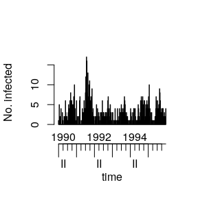

```r
library(surveillance)
library(hhh4addon)
data("salmonella.agona") # get data
# convert old "disProg" to new "sts" data class
salmonella <- disProg2sts(salmonella.agona)
# plot data:
plot(salmonella)
```

First we fit a univariate `hhh4` model with only first lags and seasonality in both the endemic (`en`) and epidemic/autoregressive (`ar`) component, i.e.
$$\mu_t = \nu_t + \phi_t X_{t - 1}$$
$$\log(\nu_t) = \alpha^{(\nu)} + \beta^{(\nu)} \sin(2\pi t/\omega) + \gamma^{(\nu)} \cos(2\pi t/\omega)$$
$$\log(\phi_t) = \alpha^{(\phi)} + \beta^{(\phi)} \sin(2\pi t/\omega) + \gamma^{(\phi)} \cos(2\pi t/\omega)$$

```r
control_salmonella <- list(end = list(f = addSeason2formula(~ 1)),
                            ar = list(f = addSeason2formula(~ 1)),
                            family = "NegBin1", subset = 6:312)
# Note: we fit to subset 6:312 to ensure comparability with the higher-order lag
# models fitted next.
fit_salmonella_ar1 <- hhh4(salmonella, control_salmonella) # use regular hhh4 function
AIC(fit_salmonella_ar1)
```

```
## [1] 1229.134
```

Next we fit a higher-order lag model with
$$\mu_t = \nu_t + \lambda_{it}\sum_{d = 1}^5 \lfloor u_d\rfloor X_{t - d},$$
geometric lag weights $u_d$ and a fixed value of $\alpha = 0.8$. We fit the model to data from week 6 onwards.

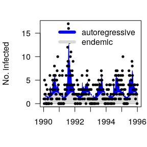

```r
par_lag_08 <- log(0.8/(1 - 0.8)) # the par_lag value corresponding to alpha = 0.8
control_salmonella_08 <- list(end = list(f = addSeason2formula(~ 1)),
                              ar = list(f = addSeason2formula(~ 1)),
                              funct_lag = geometric_lag, # default
                              max_lag = 5, # default
                              par_lag = par_lag_08, # new parameter
                              family = "NegBin1", subset = 6:312)
# Note that funct_lag = geometric_lag and max_lag = 5 are the defaults in hhh4lag and
# would not need to be specified explicitly.
fit_salmonella_geom_08 <- hhh4_lag(salmonella, control_salmonella_08) # now use hhh4lag
plot(fit_salmonella_geom_08, names = "")
```

```r
AIC(fit_salmonella_geom_08)
```

```
## [1] 1225.157
```

We can see that in terms of AIC this model is better than the previously fitted model with only first lags. To estimate `par_lag` (i.e. a suitable transformation of $\alpha$) from the data we can use the wrapper `profile_par_lag` which re-fits the model for different values of `par_lag` and uses numerical optimization (`optim`) to find the optimal one ($\alpha$ is thus estimated via a profile likelihood approach).

```r
control_salmonella_geom <- list(end = list(f = addSeason2formula(~ 1)),
                                ar = list(f = addSeason2formula(~ 1)),
                                funct_lag = geometric_lag,
                                max_lag = 5,
                                family = "NegBin1", subset = 6:312)
fit_salmonella_geom <- profile_par_lag(salmonella, control_salmonella_geom)
AIC(fit_salmonella_geom)
```

```
## [1] 1224.65
```

```r
summary(fit_salmonella_geom)
```

```
##
## Call:
## hhh4_lag(stsObj = stsObj, control = control)
##
## Coefficients:
##                         Estimate  Std. Error
## ar.1                    -0.99658   0.26263
## ar.sin(2 * pi * t/52)   -0.34039   0.20947
## ar.cos(2 * pi * t/52)   -0.64112   0.28667
## end.1                    0.37801   0.15091
## end.sin(2 * pi * t/52)  -0.25764   0.15369
## end.cos(2 * pi * t/52)   0.10855   0.17548
## overdisp                 0.14835   0.04328
##
## Distributed lags used (max_lag = 5). Weights: 0.56; 0.25; 0.11; 0.05; 0.02
## Use distr_lag() to check the applied lag distribution and parameters.
##
## Log-likelihood:   -604.32
## AIC:              1224.65
## BIC:              1254.46
##
## Number of units:        1
## Number of time points:  307
```

The best fit is achieved with $\alpha = 0.56$, i.e. almost half of the contribution of the epidemic contribution comes from lags of order larger than one (the standardized lag weights are stored in `fit_salmonella_geom$distr_lag`).

An (older) alternative in order to estimate $\alpha$ is `fit_par_lag` which instead of applying `optim` fits the model for a vector of values for `par_lag` provided by the user (argument `range_par`). Under certain circumstances this is computationally faster than the use of `optim`.

```r
grid_alpha <- seq(from = 0.01, to = 0.99, by = 0.02)
grid_par_lag <- log(grid_alpha/(1 - grid_alpha)) # move to logit scale
fit_salmonella_geom_grid <- fit_par_lag(salmonella, control_salmonella_geom,
                                   range_par = grid_par_lag)
```

The function `fit_par_lag` returns a list containing the best model (`$best_mod`) and the AIC values of the models corresponding to the different values of `par_lag` (`$AICs`). We can thus plot the AIC as a function of $\alpha$.

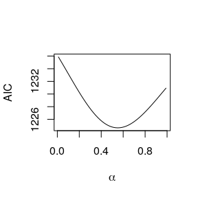

```r
plot(grid_alpha, fit_salmonella_geom_grid$AICs, type = "l",
     xlab = expression(alpha), ylab = "AIC")
```

A remark on the computation of the AIC values: The AIC of a model which was fitted with `fit_par_lag` or `profile_par_lag` is 2 points higher than that of a model with the same value of `par_lag`, but specified manually instead of being estimated. This is due to the loss of one degree of freedom.

```r
par_lag_0.56 <- log(0.56/(1 - 0.56)) # par_lag value corresponding to alpha = 0.56
control_salmonella_geom.056 <- list(end = list(f = addSeason2formula(~ 1)),
                            ar = list(f = addSeason2formula(~ 1), use_distr_lag = TRUE),
                            par_lag = par_lag_0.56,
                            family = "NegBin1", subset = 6:312)
fit_salmonella_geom.056 <- hhh4_lag(salmonella, control_salmonella_geom.056)
AIC(fit_salmonella_geom.056); AIC(fit_salmonella_geom); AIC(fit_salmonella_geom_grid$best_mod)
```

```
## [1] 1222.654
```

```
## [1] 1224.65
```

```
## [1] 1224.65
```

For comparison we also fit models with Poisson and AR(2) lags.

```r
# Poisson lags:
control_salmonella_pois <- control_salmonella
control_salmonella_pois$funct_lag <- poisson_lag
fit_salmonella_pois <- profile_par_lag(salmonella, control_salmonella_pois)
AIC(fit_salmonella_pois)
```

```
## [1] 1225.025
```

```r
# AR(2) lags:
control_salmonella_ar2 <- control_salmonella
control_salmonella_ar2$funct_lag <- ar2_lag
fit_salmonella_ar2 <- profile_par_lag(salmonella, control_salmonella_ar2)
AIC(fit_salmonella_ar2)
```

```
## [1] 1226.999
```

These parameterizations lead to a slightly worse model fit than the geometric lags weights.

Most of the functionality for `hhh4` objects is by now also available for `hhh4lag` objects (as returned by `hhh4lag`, `profile_par_lag` and `fit_par_lag`). For instance we can simulate from a fitted model. Note that in this case the starting values need to be specified as a matrix with `max_lag` rows.

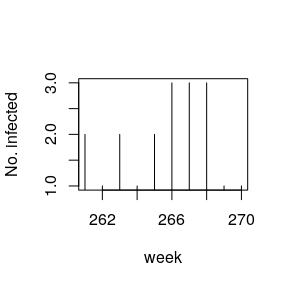

```r
# simulate 1000 trajectories for weeks 261 through 270, using values from
# 256 through 260 as starting values:
set.seed(17)
sim <- simulate(fit_salmonella_geom, subset = 261:270,
                y.start = fit_salmonella_geom$stsObj@observed[256:260, , drop = FALSE],
                nsim = 1000, simplify = TRUE)
# plot one trajectory:
plot(261:270, sim[, , 1], type = "h", xlab = "week", ylab = "No. infected")
```

Also, we can generate rolling one-week-ahead forecasts (i.e. from models which are iteratively re-fitted each week). This is done using the new function `hhh4addon:oneStepAhead_hhh4lag` (the function `surveillance:oneStepAhead` cannot be applied and will throw an error). By default the lag weighting parameter `par_lag` is not re-fitted (as this can lead to quite long computation times); to re-fit it set the argument `refit_par_lag` to `TRUE`. The result of `hhh4addon:oneStepAhead_hhh4lag` can be handled just like the return from `surveillance:oneStepAhead` would. We illustrate this for weeks 261–312 as the validation period.

```r
owa_forecasts_geom <- oneStepAhead_hhh4lag(fit_salmonella_geom,
                                      tp = c(260, 311), refit_par_lag = FALSE)
```

```
## Lag weights are not re-estimated for the one-step-ahead forecasts (set refit_par_lag = TRUE to re-fit them).
```

```r
# forecasts are done for tp[1] + 1, tp[2] + 1, ...
colMeans(scores(owa_forecasts_geom))
```

```
##     logs      rps      dss      ses
## 2.044585 1.125719 2.553112 4.517066
```

```r
# for comparison: model with only first lags:
owa_forecasts_ar1 <- oneStepAhead(fit_salmonella_ar1,
                                      tp = c(260, 311))
colMeans(scores(owa_forecasts_ar1)) # average scores
```

```
##     logs      rps      dss      ses
## 2.058342 1.116286 2.664664 4.376845
```

The geometric-lag model thus performs slightly better in terms of the logarithmic and Dawid-Sebastiani scores, but worse in terms of the ranked probability score (all scores are negatively oriented).

## Computing predictive and marginal moments

The second functionality of `hhh4addon` concerns predictive and marginal (stationary or periodically stationary) moments. These quantities can be computed without the need for simulation for the endemic-epidemic class, see Held, Meyer and Bracher (2017) and Bracher and Held (2019) for the theoretical background.

To illustrate the use of predictive moments we re-fit the above models to weeks 6–260 of the `salmonella.agona` data. The rest is again kept for validation of our predictions.

```r
control_salmonella.sub <- list(end = list(f = addSeason2formula(~ 1), lag = 1),
                            ar = list(f = addSeason2formula(~ 1), lag = 1),
                            family = "NegBin1", subset = 6:260)
fit_salmonella_ar1.sub <- hhh4(salmonella, control_salmonella.sub)
fit_salmonella_geom.sub <- profile_par_lag(salmonella, control_salmonella.sub)
```

Predictive moments for weeks 261, 262, … can now be calculated and plotted. Note that these correspond to a *path forecast* rather than a weekly updated rolling forecast as before, i.e. the forecasts for weeks 261, 262,… are all conditioned on the observation from week 260.

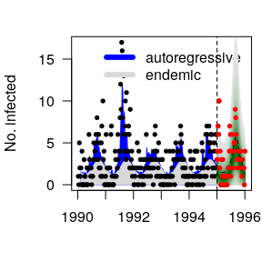

```r
pred_mom_ar1 <- predictive_moments(fit_salmonella_ar1.sub, t_condition = 260,
                               lgt = 52, return_Sigma = TRUE)
# if return_Sigma == TRUE the full predictive covariance function is returned
# this may be costly in terms of storage for complex models and long forecasts.
pred_mom_geom <- predictive_moments(fit_salmonella_geom.sub,
                                    t_condition = 260, lgt = 52, return_Sigma = TRUE)

plot(fit_salmonella_ar1.sub, names = "")
fanplot_prediction(pred_mom_geom, add = TRUE)
```

The fanplots shown here are based on negative binomial approximations of the predictive distributions via the first two moments. We can also use these predictive moments to evaluate the Dawid-Sebastiani score of the path forecasts (a proper scoring rule for predictive model assessment, Held et al 2017).

```r
# Note that ds_score requires that the full predictive covariance matrix is
# available, i.e. compute_Sigma = TRUE is used in predictive_moments.
ds_score_hhh4(pred_mom_ar1)
```

```
## [1] 1.43501
```

```r
ds_score_hhh4(pred_mom_geom)
```

```
## [1] 1.431232
```

The David-Sebastiani score is negatively oriented here, i.e. the prediction from the model `fit_salmonella_geom.sub` with geometric lags is slightly better than the one from the simpler `fit_salmonella.sub`.

The `predictive_moments` function can also be used to check that the simulation functions are doing the right thing. Here we can re-use the previously simulated data:

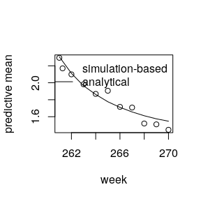

```r
cond_mom_geom_260 <- predictive_moments(fit_salmonella_geom, t_condition = 260, lgt = 10)
plot(261:270, apply(sim, 1:2, mean), xlab = "week", ylab = "predictive mean")
lines(261:270, cond_mom_geom_260$mu_matrix)
legend("topright", pch = c(1, NA), lty = c(NA, 1),
       legend = c("simulation-based", "analytical"), bty = "n")
```

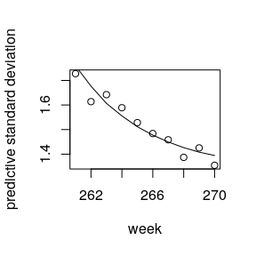

```r
plot(261:270, apply(sim, 1:2, sd), xlab = "week", ylab = "predictive standard deviation")
lines(261:270, sqrt(cond_mom_geom_260$var_matrix))
```

The function `stationary_moments` can be applied in the same way (without specifying a `t_condition` and `lgt`) to obtain the marginal moments of a fitted model. Note that this is only possible for models with either time-constant parameters (stationary moments) or periodically varying parameters (periodically stationary moments). For horizons exceeding a few weeks the predictive and marginal moments are indistinguishable (as the forecast goes to the periodically stationary behaviour of the model).

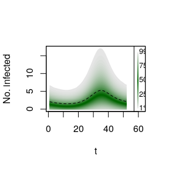

```r
marg_mom_geom <- stationary_moments(fit_salmonella_geom)
fanplot_stationary(marg_mom_geom, timepoints = 1:52, add_legend = TRUE)
```

# References

Bracher, J. and L. Held (2019). Endemic-epidemic models with discrete-time serial interval distributions for infectious disease prediction. Preprint: https://arxiv.org/abs/1901.03090.

Bracher, J. and Held, L. (2017) Periodically stationary multivariate autoregressive models. Preprint: https://arxiv.org/abs/1707.04635

Held, L., S. Meyer, and J. Bracher (2017). Probabilistic forecasting in infectious disease epidemiology: the 13th Armitage lecture. *Statistics in Medicine* 36 (22), 3443–3460.

Meyer, S., L. Held, and M. Höhle (2017). Spatio-temporal analysis of epidemic phenomena using the R package surveillance. *Journal of Statistical Software* 77 (11), 1–55.